# Gentle Intro to Implicit SGD

Panos Toulis (http://ptoulis.com)

04/14/2022

### 1. Introduction

This document offers a practical introduction to implicit stochastic gradient descent (ISGD), which is a stable variant to the popular SGD method. In general, SGD is used to fit large-scale statistical and machine learning (ML) models thanks to its computational efficiency, but it can be numerically unstable. ISGD resolves some of these issues but its implementation can be challenging in practice.

### 2. Basic idea of SGD

Suppose we model the response $Y\in\mathbb{R}$ through covariates (features) $X\in\mathbb{R}^p$. We observe data $(x_i, y_i), i=1, \ldots, n$. Let’s use “ordinary least squares” (OLS), i.e., aim to minimize $l(\theta) = (1/2) \sum_{j=1}^n (y_j - x_j'\theta)^2$. When $n$ is large, the minimization can be tedious, especially when it involves calculating the Hessian. SGD simplifies the task considerably by instead suggesting the iteration
$$\theta_i = \theta_{i-1} + \gamma_i (y_{I} - x_{I}'\theta_{i-1}) x_{I},~~i >0.$$
Here, $I\sim \mathrm{Unif}(1, \ldots, n)$ is a random datapoint at each iteration $i$, and, typically, $\gamma_i=\gamma_1/i > 0$.

Here is one generic implementation of the above SGD procedure. First, we start with code that implements a general stochastic approximation procedure, and a routine for visualizations.

```r
rm(list=ls())
# Generic stochastic approximation
sa = function(y_arg, X_arg, update_fn, theta0=rep(0, ncol(X_arg)), gamma1=1, npass=1, target=NULL, last=TRUE) {
  n = length(y_arg)
  theta = matrix(0, nrow=n*npass, ncol=length(theta0))  # path
  theta[1,] = theta0    # initialization
  colnames(theta) = colnames(X)
  for(i in seq(2, npass*n)) {
    theta_old = theta[i-1,]     # old estimate
    I = sample(1:n, size=1)       # random datapoint
    x_I = X_arg[I,]; y_I = y_arg[I]
    lr = gamma1/i   # learning rate

    theta[i,] = as.numeric(update_fn(y_I, x_I, theta_old, lr)) # new estimate
  }

  # visualize if we know target values
  if(!is.null(target)) { viz(target, theta0, theta) }

  if(last) { return(theta[nrow(theta), ]) } else { return(theta) }
}

# visualization of estimation accuracy
viz = function(target, theta0, theta) {
  est = theta[nrow(theta),] # last estimate
  plot(est, target, pch=20, cex=3, main="blue=initial, black=final",
       xlab="sgd estimate") # estimate wrt target
  legend("bottomright", legend="y=x line", lty=3, col="red")
  points(theta0, target, pch=20, cex=2, col="blue") # initial point wrt target
  abline(0, 1, col="red", lty=3)
  arrows(theta0, target, est, target, lty=2, col="blue", code=2, length=0.15)
}
```

The SGD method in the OLS model is then implemented by using `sa` with the following update:

```r
sgd_update = function(y_I, x_I, theta_old, lr) {
  y_hat = sum(x_I*theta_old)  # predicted value of y
  theta_old + lr*(y_I - y_hat)*x_I  # ols sgd
}
```

Despite its simplicity, SGD can be unstable as it can be *very sensitive* to all its three hyperparameters:

- `theta0`, the starting point;
- `gamma1`, the learning rate and
- `npass`, the number of *passes* over the data.

Let’s investigate this through a data example.

### 3. Data example

```r
set.seed(41100)
attach(read.csv("https://raw.githubusercontent.com/ptoulis/datasets/main/hubble.csv"))
X = cbind(1, distance) # covariates
y = velocity    # response
```

Here, we model the speed of galaxies (`y`) moving away from earth and their distance (`X`). [Hubble’s law](https://en.wikipedia.org/wiki/Hubble%27s_law) suggests that these two quantities are proportional to each other. So, the OLS model above is a good choice. Using `lm` we calculate

```r
fit = lm(y ~ X+0)
summary(fit)
```

```
##
## Call:
## lm(formula = y ~ X + 0)
##
## Residuals:
##     Min      1Q  Median      3Q     Max
## -735.14 -132.92  -22.57  171.74  558.61
##
## Coefficients:
##           Estimate Std. Error t value Pr(>|t|)
## X            6.696    126.557   0.053    0.958
## Xdistance   76.127      9.493   8.019 5.68e-08 ***
## ---
## Signif. codes:  0 '***' 0.001 '**' 0.01 '*' 0.05 '.' 0.1 ' ' 1
##
## Residual standard error: 264.7 on 22 degrees of freedom
## Multiple R-squared:  0.9419, Adjusted R-squared:  0.9367
## F-statistic: 178.5 on 2 and 22 DF,  p-value: 2.528e-14
```

```r
b_ols = coef(fit)
```

The “true” slope is 76.127 and is highly significant. Let’s see what we get with SGD if we let all parameters at their default value:

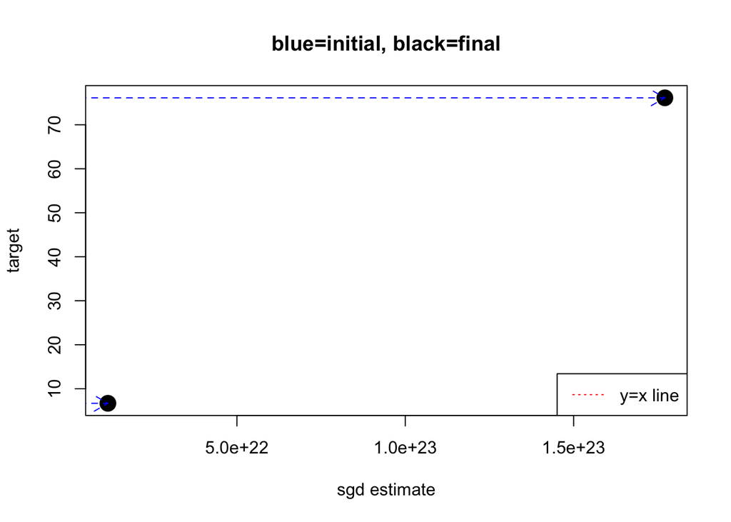

```
##                  distance
## 1.169263e+22 1.770883e+23
```

```r
sa(y, X, sgd_update, target=b_ols)
```

We see that SGD completely diverged! Let’s see whether we can address this issue by increasing the number of passes over the data:

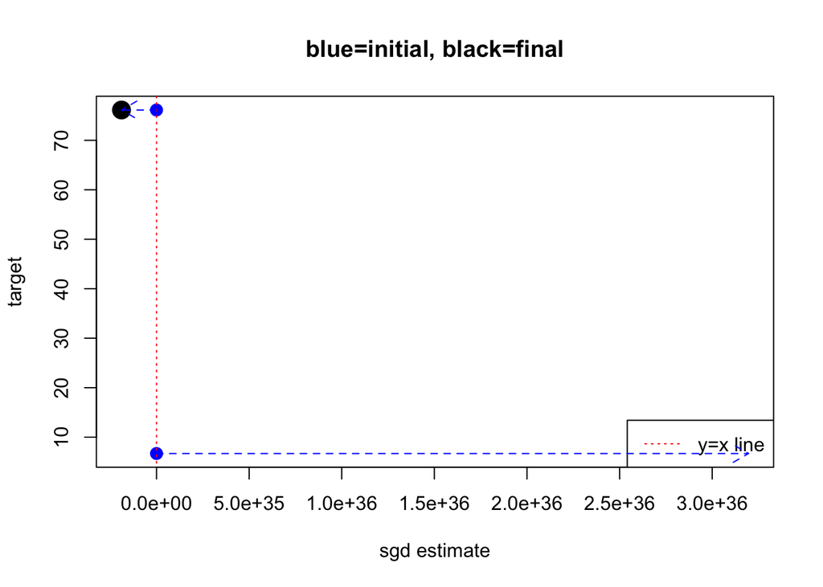

```
##                    distance
##  3.196091e+36 -1.890527e+35
```

```r
sa(y, X, sgd_update, npass=100, target=b_ols)
```

That didn’t help. It is clear that the learning rate is too large. We can try to lower the learning rate:

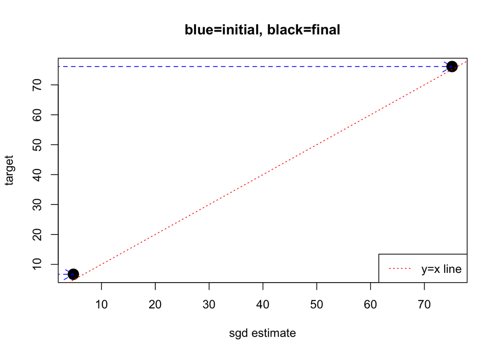

```
##            distance
##  4.775514 75.139581
```

```r
sa(y, X, sgd_update, gamma1=0.01, target=b_ols)
```

Much better. We see that the SGD estimates align with the target estimates. Increasing the learning rate a bit more, however, breaks SGD again:

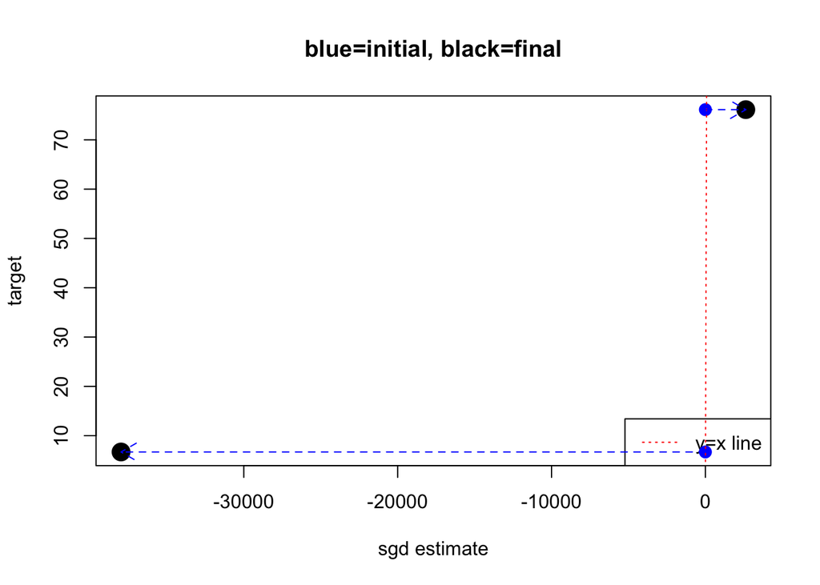

```
##              distance
## -37976.597   2626.121
```

```r
sa(y, X, sgd_update, gamma=0.1, npass=100, target=b_ols)
```

We see that SGD is extremely sensitive to its hyperparameters. This makes its application quite challenging, which unsettles many users.

ISGD can help!

### 4. Implicit SGD

ISGD is a variant of SGD that is numerically much more stable. The idea is similar to optimization methods that backtrack when the update is too large. The really cool aspect of ISGD is that it automatically calculates the amount of backtracking that is required.

Roughly speaking, you obtain ISGD by substituting $\theta_{i-1}$ with $\theta_i$ in the likelihood portion of the SGD update. In the context of OLS, this means
$$\theta_i = \theta_{i-1} + \gamma_i (y_{I} - x_{I}'\theta_{i}) x_{I},~~i >0.$$
Note that $\theta_i$ now appears on both sides, hence the update is implicit. Solving for $\theta_i$ we get
$$\theta_i = \theta_{i-1} + \frac{\gamma_i}{1+\gamma_i||x_I||^2} (y_{I} - x_{I}'\theta_{i-1}) x_{I},~~i >0.$$
This is also known as “normalized least mean squares” filter ([NLMS](https://en.wikipedia.org/wiki/Least_mean_squares_filter)) in signal processing. Here is a quick implementation of this idea in the OLS model:

```r
isgd_update = function(y_I, x_I, theta_old, lr) {
  y_hat = sum(x_I*theta_old)  # predicted value of y
  im_ftr = lr/ (1+lr*sum(x_I^2))  # specific to ISGD
  theta_old + im_ftr*(y_I - y_hat)*x_I  # ols sgd
}
```

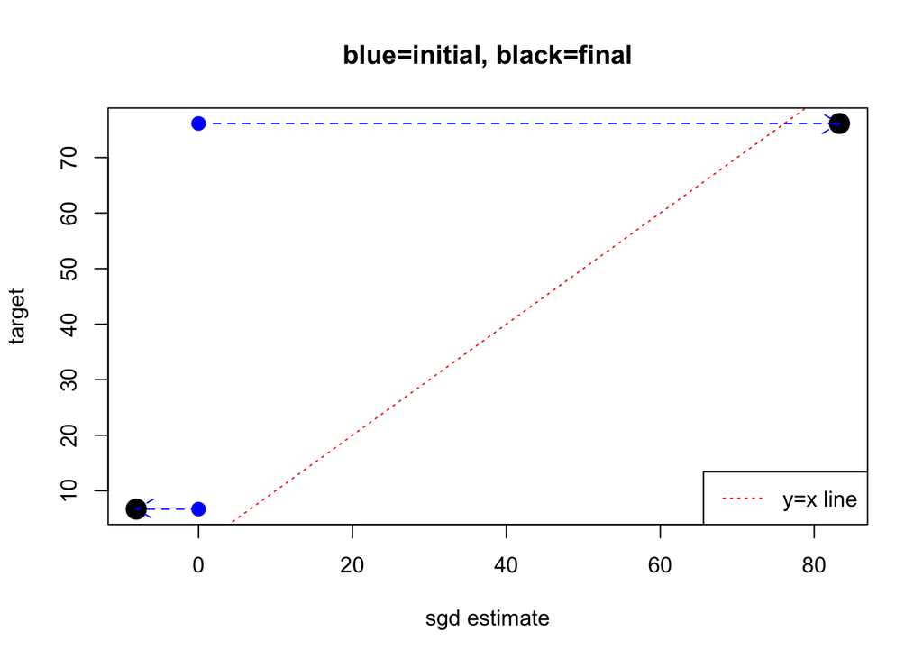

```
##            distance
## -8.097782 83.287398
```

```r
sa(y, X, isgd_update, target=b_ols)
```

Let’s try to increase `npass` to improve our convergence.

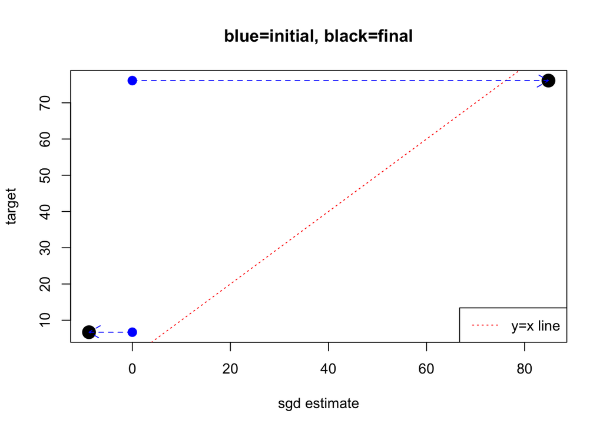

```
##            distance
## -8.829035 84.855247
```

```r
sa(y, X, isgd_update, npass=100, target=b_ols)
```

Let’s see specifically how the ISGD estimate for the slope changes over iterations:

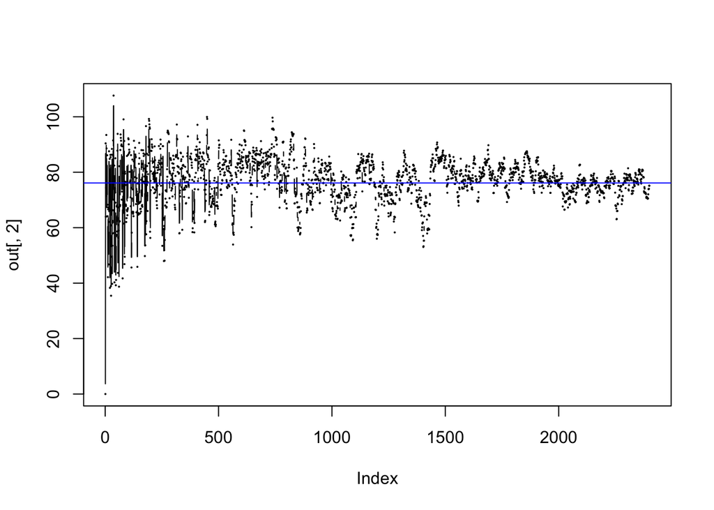

```r
out = sa(y, X, isgd_update, npass=100, last=F)
plot(out[,2], type="b",pch=20, cex=0.2)
abline(h=b_ols[2], col="blue")
```

We see that ISGD is bouncing around the target value, suggesting that the learning rate is too high and does not allow ISGD to settle. This is actually a **feature** of ISGD: It is very stable but we still need to tune the learning rate to get optimal performance. What we mostly gain from ISGD is that we don’t have to worry about numerical instabilities or divergence!

Let’s try again with a smaller learning rate:

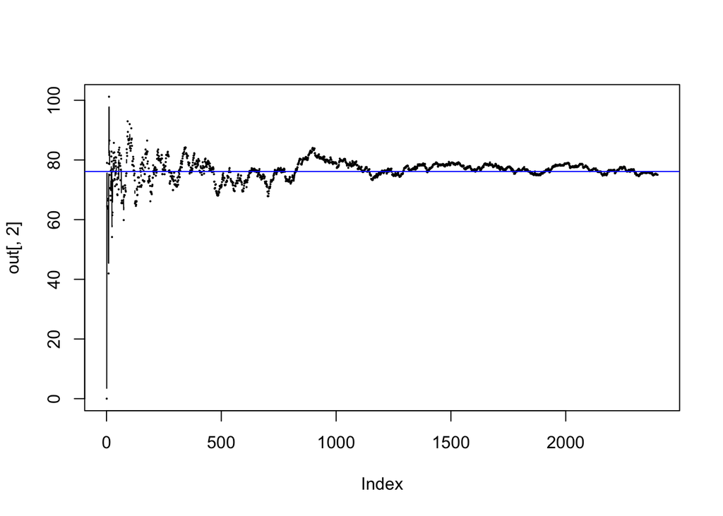

```r
out = sa(y, X, isgd_update, gamma1=0.1, npass=100, last=F)
plot(out[,2], type="b",pch=20, cex=0.2)
abline(h=b_ols[2], col="blue")
```

Much better! Recall that this configuration was actually quite bad for SGD.

### 5. Summary

- Despite its simplicity, SGD is *very sensitive* to all its hyperparameters.
- ISGD is a numerically stable variant of SGD.
- Roughly speaking, to derive ISGD we substitute $\theta_{i-1}$ with $\theta_i$ in the likelihood portion of the SGD update. In OLS, such implicit update can be exactly solved.
- What we gain from ISGD is numerical stability. We still need to tune the learning rate to get optimal performance.

The following questions remain:

1. How to tune the hyperparameters of SGD in practice? What changes for ISGD?
2. How to implement ISGD in other models, such as logistic regression?
3. Can we get statistical significance from SGD/ISGD procedures?

These question are quite subtle and require additional discussion. I hope to get back to these soon.

### 6. More reading

- (Robbins and Monro, 1951): Seminal paper on stochastic approximations. SGD is a special case.
- (Zhang, 2004): One of the first papers introducing SGD in machine learning.
- (Bottou, 2010): Describes the principles behind SGD and its generality over various ML models.
- (Bertsekas, 2011): Analyzes convergence properties of incremental proximal methods, which is equivalent to ISGD in many settings.
- (Toulis et al, 2014): Implicit SGD for generalized linear models with simple algorithms for concrete implementation. Also derives the asymptotic variance of SGD/ISGD, and discusses ISGD’s stability benefits.